# **SuperKart Sales Prediction**

## **Context:**

A sales forecast is a prediction of future sales revenue based on historical data, industry trends, and the status of the current sales pipeline. Businesses use the sales forecast to estimate weekly, monthly, quarterly, and annual sales totals. It is extremely important for a company to make an accurate sales forecast as it adds value across an organization and helps the different verticals to chalk out their future course of action. Forecasting helps an organization plan its sales operations by region and provides valuable insights to the supply chain team regarding the procurement of goods and materials. An accurate sales forecast process has many benefits which include improved decision-making about the future and reduction of sales pipeline and forecast risks. Moreover, it helps to reduce the time spent in planning territory coverage and establish benchmarks that can be used to assess trends in the future.

## **Objective:**

SuperKart is an organization that owns a chain of supermarkets and food marts providing a wide range of products. They want to predict the future sales revenue of its different outlets so that they can strategize their sales operation across different tier cities and plan their inventory accordingly. To achieve this purpose, SuperKart has hired a data science firm, shared the sales records of its various outlets for the previous quarter, and asked the firm to come up with a suitable model to predict the total sales of the stores for the upcoming quarter.

## **Data Description:**

The data contains the different attributes of the various products and stores. The detailed data dictionary is given below.

- Product_Id - unique identifier of each product, each identifier having two letters at the beginning followed by a number.
- Product_Weight - the weight of each product
- Product_Sugar_Content - sugar content of each product like low sugar, regular, and no sugar
- Product_Allocated_Area - the ratio of the allocated display area of each product to the total display area of all the products in a store
- Product_Type - broad category for each product like meat, snack foods, hard drinks, dairy, canned, soft drinks, health and hygiene, baking goods, bread, breakfast, frozen foods, fruits and vegetables, household, seafood, starchy foods, others
- Product_MRP - maximum retail price of each product
- Store_Id - unique identifier of each store
- Store_Establishment_Year - the year in which the store was established
- Store_Size - the size of the store depending on sq. feet like high, medium, and low
- Store_Location_City_Type - the type of city in which the store is located like Tier 1, Tier 2, and Tier 3. Tier 1 consists of cities where the standard of living is comparatively higher than its Tier 2 and Tier 3 counterparts.
- Store_Type - the type of store depending on the products that are being sold there like Departmental Store, Supermarket Type 1, Supermarket Type 2, and Food Mart
- Product_Store_Sales_Total - total revenue generated by the sale of that particular product in that particular store

## **Model Serialization**

After building the regression model to predict store sales, we will serialize it to ensure it can be reused and deployed efficiently. Model serialization allows us to save the trained model and later load it for making predictions without retraining. We will use popular serialization formats such as **Pickle** or **Joblib** for this purpose.

## **Technology Used**

- **Python (Pandas, NumPy, Scikit-learn)** – Data preprocessing, model building
- **Matplotlib, Seaborn** – Data visualization
- **Pickle/Joblib** – Model serialization
- **Flask/FastAPI** – API deployment
- **Docker** – Containerization
- **Git** – Version control
- **Pipeline** – Deployment automation
- **AWS/Google Cloud** – Cloud hosting

## **Importing the necessary libraries and overview of the dataset**

```python
# 📌 Libraries for data manipulation
import numpy as np
import pandas as pd
import os

# 📌 Libraries for data visualization
import matplotlib.pyplot as plt
import seaborn as sns

# 📌 Configure Pandas display options
pd.set_option("display.max_columns", None)  # Show all columns
pd.set_option("display.max_rows", 100)      # Limit displayed rows

# 📌 Library for splitting the dataset
from sklearn.model_selection import train_test_split

# 📌 Libraries for building a linear regression model
from statsmodels.formula.api import ols
import statsmodels.api as sm
from sklearn.linear_model import LinearRegression, Ridge
from sklearn.model_selection import GridSearchCV

# 📌 Libraries for data preprocessing and pipelines
from sklearn.preprocessing import OneHotEncoder, StandardScaler
from sklearn.compose import ColumnTransformer
from sklearn.pipeline import Pipeline

# 📌 Library for saving and loading models
import joblib

# 📌 Ignore warnings
import warnings
warnings.filterwarnings("ignore")
```

### **Importing the Dataset**

```python
os.chdir("C:/Users/claud/Documents/Machine learning MIT/Regression_Techniques")
kart = pd.read_csv("SuperKart-2.csv")
```

```python
# Copying data to another variable to avoid any changes to original data
data = kart.copy()
```

### **View the first and last 5 rows of the dataset**

```python
data.head()
```

|  | Product_Id | Product_Weight | Product_Sugar_Content | Product_Allocated_Area | Product_Type | Product_MRP | Store_Id | Store_Establishment_Year | Store_Size | Store_Location_City_Type | Store_Type | Product_Store_Sales_Total |
| --- | --- | --- | --- | --- | --- | --- | --- | --- | --- | --- | --- | --- |
| 0 | FD6114 | 12.66 | Low Sugar | 0.027 | Frozen Foods | 117.08 | OUT004 | 2009 | Medium | Tier 2 | Supermarket Type2 | 2842.40 |
| 1 | FD7839 | 16.54 | Low Sugar | 0.144 | Dairy | 171.43 | OUT003 | 1999 | Medium | Tier 1 | Departmental Store | 4830.02 |
| 2 | FD5075 | 14.28 | Regular | 0.031 | Canned | 162.08 | OUT001 | 1987 | High | Tier 2 | Supermarket Type1 | 4130.16 |
| 3 | FD8233 | 12.10 | Low Sugar | 0.112 | Baking Goods | 186.31 | OUT001 | 1987 | High | Tier 2 | Supermarket Type1 | 4132.18 |
| 4 | NC1180 | 9.57 | No Sugar | 0.010 | Health and Hygiene | 123.67 | OUT002 | 1998 | Small | Tier 3 | Food Mart | 2279.36 |

**Observation:**

- The sales of the store are indicated by the variable Product_Store_Sales_Total is the target variable and the rest of the variables are independent variables based on which we will predict the total sales of the stores for the upcoming quarter.

```python
data.tail()
```

|  | Product_Id | Product_Weight | Product_Sugar_Content | Product_Allocated_Area | Product_Type | Product_MRP | Store_Id | Store_Establishment_Year | Store_Size | Store_Location_City_Type | Store_Type | Product_Store_Sales_Total |
| --- | --- | --- | --- | --- | --- | --- | --- | --- | --- | --- | --- | --- |
| 8758 | NC7546 | 14.80 | No Sugar | 0.016 | Health and Hygiene | 140.53 | OUT004 | 2009 | Medium | Tier 2 | Supermarket Type2 | 3806.53 |
| 8759 | NC584 | 14.06 | No Sugar | 0.142 | Household | 144.51 | OUT004 | 2009 | Medium | Tier 2 | Supermarket Type2 | 5020.74 |
| 8760 | NC2471 | 13.48 | No Sugar | 0.017 | Health and Hygiene | 88.58 | OUT001 | 1987 | High | Tier 2 | Supermarket Type1 | 2443.42 |
| 8761 | NC7187 | 13.89 | No Sugar | 0.193 | Household | 168.44 | OUT001 | 1987 | High | Tier 2 | Supermarket Type1 | 4171.82 |
| 8762 | FD306 | 14.73 | Low Sugar | 0.177 | Snack Foods | 224.93 | OUT002 | 1998 | Small | Tier 3 | Food Mart | 2186.08 |

### **Understand the shape of the dataset**

```python
print(f"There are {data.shape[0]} rows and {data.shape[1]} columns.")
```

```
There are 8763 rows and 12 columns.
```

### **Check the data types of the columns for the dataset**

```python
data.info()
```

```
<class 'pandas.core.frame.DataFrame'>
RangeIndex: 8763 entries, 0 to 8762
Data columns (total 12 columns):
 #   Column                     Non-Null Count  Dtype
---  ------                     --------------  -----
 0   Product_Id                 8763 non-null   object
 1   Product_Weight             8763 non-null   float64
 2   Product_Sugar_Content      8763 non-null   object
 3   Product_Allocated_Area     8763 non-null   float64
 4   Product_Type               8763 non-null   object
 5   Product_MRP                8763 non-null   float64
 6   Store_Id                   8763 non-null   object
 7   Store_Establishment_Year   8763 non-null   int64
 8   Store_Size                 8763 non-null   object
 9   Store_Location_City_Type   8763 non-null   object
 10  Store_Type                 8763 non-null   object
 11  Product_Store_Sales_Total  8763 non-null   float64
dtypes: float64(4), int64(1), object(7)
memory usage: 821.7+ KB
```

**Observations:**

- Product_Weight, Product_Allocated_Area, Product_MRP, Store_Establishment_Year, and Product_Store_Sales_Total are the numeric columns while the rest are object ones.
- There are a total of **8763 non-null observations in each of the columns**. This indicates that there are **no missing values** in the data.

### **Checking for missing values in the dataset**

```python
# Checking for missing values in the data
data.isnull().sum()
```

```
Product_Id                   0
Product_Weight               0
Product_Sugar_Content        0
Product_Allocated_Area       0
Product_Type                 0
Product_MRP                  0
Store_Id                     0
Store_Establishment_Year     0
Store_Size                   0
Store_Location_City_Type     0
Store_Type                   0
Product_Store_Sales_Total    0
dtype: int64
```

**Observation:**

- There are no missing values in the data.

```python
# Checking for duplicate values
data.duplicated().sum()
```

```
0
```

**Observation:**

- There are no duplicate values in the data.

## **Exploratory Data Analysis**

**Let's check the statistical summary of the data.**

```python
data.describe(include = "all").T
```

|  | count | unique | top | freq | mean | std | min | 25% | 50% | 75% | max |
| --- | --- | --- | --- | --- | --- | --- | --- | --- | --- | --- | --- |
| Product_Id | 8763 | 8763 | FD6114 | 1 | NaN | NaN | NaN | NaN | NaN | NaN | NaN |
| Product_Weight | 8763.0 | NaN | NaN | NaN | 12.653792 | 2.21732 | 4.0 | 11.15 | 12.66 | 14.18 | 22.0 |
| Product_Sugar_Content | 8763 | 4 | Low Sugar | 4885 | NaN | NaN | NaN | NaN | NaN | NaN | NaN |
| Product_Allocated_Area | 8763.0 | NaN | NaN | NaN | 0.068786 | 0.048204 | 0.004 | 0.031 | 0.056 | 0.096 | 0.298 |
| Product_Type | 8763 | 16 | Fruits and Vegetables | 1249 | NaN | NaN | NaN | NaN | NaN | NaN | NaN |
| Product_MRP | 8763.0 | NaN | NaN | NaN | 147.032539 | 30.69411 | 31.0 | 126.16 | 146.74 | 167.585 | 266.0 |
| Store_Id | 8763 | 4 | OUT004 | 4676 | NaN | NaN | NaN | NaN | NaN | NaN | NaN |
| Store_Establishment_Year | 8763.0 | NaN | NaN | NaN | 2002.032751 | 8.388381 | 1987.0 | 1998.0 | 2009.0 | 2009.0 | 2009.0 |
| Store_Size | 8763 | 3 | Medium | 6025 | NaN | NaN | NaN | NaN | NaN | NaN | NaN |
| Store_Location_City_Type | 8763 | 3 | Tier 2 | 6262 | NaN | NaN | NaN | NaN | NaN | NaN | NaN |
| Store_Type | 8763 | 4 | Supermarket Type2 | 4676 | NaN | NaN | NaN | NaN | NaN | NaN | NaN |
| Product_Store_Sales_Total | 8763.0 | NaN | NaN | NaN | 3464.00364 | 1065.630494 | 33.0 | 2761.715 | 3452.34 | 4145.165 | 8000.0 |

**Observations:**

**Let's check the count of each unique category in each of the categorical variables**

```python
# Making a list of all categorical variables
cat_col = list(data.select_dtypes("object").columns)

# Printing the count of each unique value
for column in cat_col:
    print(data[column].value_counts())
    print("-" * 50)
```

```
Product_Id
FD6114    1
FD8349    1
DR3530    1
NC5926    1
FD3575    1
         ..
FD2396    1
FD681     1
FD8077    1
DR3118    1
FD306     1
Name: count, Length: 8763, dtype: int64
--------------------------------------------------
Product_Sugar_Content
Low Sugar    4885
Regular      2251
No Sugar     1519
reg           108
Name: count, dtype: int64
--------------------------------------------------
Product_Type
Fruits and Vegetables    1249
Snack Foods              1149
Frozen Foods              811
Dairy                     796
Household                 740
Baking Goods              716
Canned                    677
Health and Hygiene        628
Meat                      618
Soft Drinks               519
Breads                    200
Hard Drinks               186
Others                    151
Starchy Foods             141
Breakfast                 106
Seafood                    76
Name: count, dtype: int64
--------------------------------------------------
```

[output cut: 11 more lines]

```
Name: count, dtype: int64
--------------------------------------------------
Store_Location_City_Type
Tier 2    6262
Tier 1    1349
Tier 3    1152
Name: count, dtype: int64
--------------------------------------------------
Store_Type
Supermarket Type2     4676
Supermarket Type1     1586
Departmental Store    1349
Food Mart             1152
Name: count, dtype: int64
--------------------------------------------------
```

**Observations:**

```python
# Replacing reg with Regular in Product_Sugar_Content feature
data.Product_Sugar_Content.replace(to_replace = ["reg"], value = ["Regular"], inplace = True)
```

```python
data.Product_Sugar_Content.value_counts()
```

```
Product_Sugar_Content
Low Sugar    4885
Regular      2359
No Sugar     1519
Name: count, dtype: int64
```

**Observation:**

- We can see that the Product_Id column has two characters followed by a number. Let's delve deeper and see whether they are having any relationship with the other columns or not.

```python
# Extracting the first two characters from the Product_Id column and storing it in another column
data["Product_Id_char"] = data["Product_Id"].str[:2]

data.head()
```

|  | Product_Id | Product_Weight | Product_Sugar_Content | Product_Allocated_Area | Product_Type | Product_MRP | Store_Id | Store_Establishment_Year | Store_Size | Store_Location_City_Type | Store_Type | Product_Store_Sales_Total | Product_Id_char |
| --- | --- | --- | --- | --- | --- | --- | --- | --- | --- | --- | --- | --- | --- |
| 0 | FD6114 | 12.66 | Low Sugar | 0.027 | Frozen Foods | 117.08 | OUT004 | 2009 | Medium | Tier 2 | Supermarket Type2 | 2842.40 | FD |
| 1 | FD7839 | 16.54 | Low Sugar | 0.144 | Dairy | 171.43 | OUT003 | 1999 | Medium | Tier 1 | Departmental Store | 4830.02 | FD |
| 2 | FD5075 | 14.28 | Regular | 0.031 | Canned | 162.08 | OUT001 | 1987 | High | Tier 2 | Supermarket Type1 | 4130.16 | FD |
| 3 | FD8233 | 12.10 | Low Sugar | 0.112 | Baking Goods | 186.31 | OUT001 | 1987 | High | Tier 2 | Supermarket Type1 | 4132.18 | FD |
| 4 | NC1180 | 9.57 | No Sugar | 0.010 | Health and Hygiene | 123.67 | OUT002 | 1998 | Small | Tier 3 | Food Mart | 2279.36 | NC |

```python
data["Product_Id_char"].unique()
```

```
array(['FD', 'NC', 'DR'], dtype=object)
```

```python
data.loc[data.Product_Id_char == "FD", "Product_Type"].unique()
```

```
array(['Frozen Foods', 'Dairy', 'Canned', 'Baking Goods', 'Snack Foods',
       'Meat', 'Fruits and Vegetables', 'Breads', 'Breakfast',
       'Starchy Foods', 'Seafood'], dtype=object)
```

**Observation:**

- We can see that FD is being used in the Product_Id of the food items.

```python
data.loc[data.Product_Id_char == "DR", "Product_Type"].unique()
```

```
array(['Hard Drinks', 'Soft Drinks'], dtype=object)
```

**Observation:**

- We can see that DR is being used in the Product_Id of the drinks.

```python
data.loc[data.Product_Id_char == "NC", "Product_Type"].unique()
```

```
array(['Health and Hygiene', 'Household', 'Others'], dtype=object)
```

**Observation:**

**The Product_Id column will not add any value to our analysis so let's drop it before we move forward.**

```python
# Dropping both the columns
data = data.drop(["Product_Id"], axis = 1)
```

```python
data.head()
```

|  | Product_Weight | Product_Sugar_Content | Product_Allocated_Area | Product_Type | Product_MRP | Store_Id | Store_Establishment_Year | Store_Size | Store_Location_City_Type | Store_Type | Product_Store_Sales_Total | Product_Id_char |
| --- | --- | --- | --- | --- | --- | --- | --- | --- | --- | --- | --- | --- |
| 0 | 12.66 | Low Sugar | 0.027 | Frozen Foods | 117.08 | OUT004 | 2009 | Medium | Tier 2 | Supermarket Type2 | 2842.40 | FD |
| 1 | 16.54 | Low Sugar | 0.144 | Dairy | 171.43 | OUT003 | 1999 | Medium | Tier 1 | Departmental Store | 4830.02 | FD |
| 2 | 14.28 | Regular | 0.031 | Canned | 162.08 | OUT001 | 1987 | High | Tier 2 | Supermarket Type1 | 4130.16 | FD |
| 3 | 12.10 | Low Sugar | 0.112 | Baking Goods | 186.31 | OUT001 | 1987 | High | Tier 2 | Supermarket Type1 | 4132.18 | FD |
| 4 | 9.57 | No Sugar | 0.010 | Health and Hygiene | 123.67 | OUT002 | 1998 | Small | Tier 3 | Food Mart | 2279.36 | NC |

### **Univariate Analysis**

```python
# Function to plot a boxplot and a histogram along the same scale

def histogram_boxplot(data, feature, figsize = (12, 7), kde = False, bins = None):
    """
    Boxplot and histogram combined

    data: dataframe
    feature: dataframe column
    figsize: size of figure (default (12,7))
    kde: whether to show density curve (default False)
    bins: number of bins for histogram (default None)
    """
    f2, (ax_box2, ax_hist2) = plt.subplots(
        nrows = 2,      # Number of rows of the subplot grid = 2
        sharex = True,  # x-axis will be shared among all subplots
        gridspec_kw = {"height_ratios": (0.25, 0.75)},
        figsize = figsize,
    )                   # Creating the 2 subplots
    sns.boxplot(
        data = data, x = feature, ax = ax_box2, showmeans = True, color = "violet"
    )                   # Boxplot will be created and a star will indicate the mean value of the column
    sns.histplot(
        data = data, x = feature, kde = kde, ax = ax_hist2, bins = bins, palette = "winter"
    ) if bins else sns.histplot(
        data = data, x = feature, kde = kde, ax = ax_hist2
    )                   # For histogram
    ax_hist2.axvline(
        data[feature].mean(), color = "green", linestyle = "--"
    )                   # Add mean to the histogram
    ax_hist2.axvline(
        data[feature].median(), color = "black", linestyle = "-"
    )                   # Add median to the histogram
```

**Product_Weight**

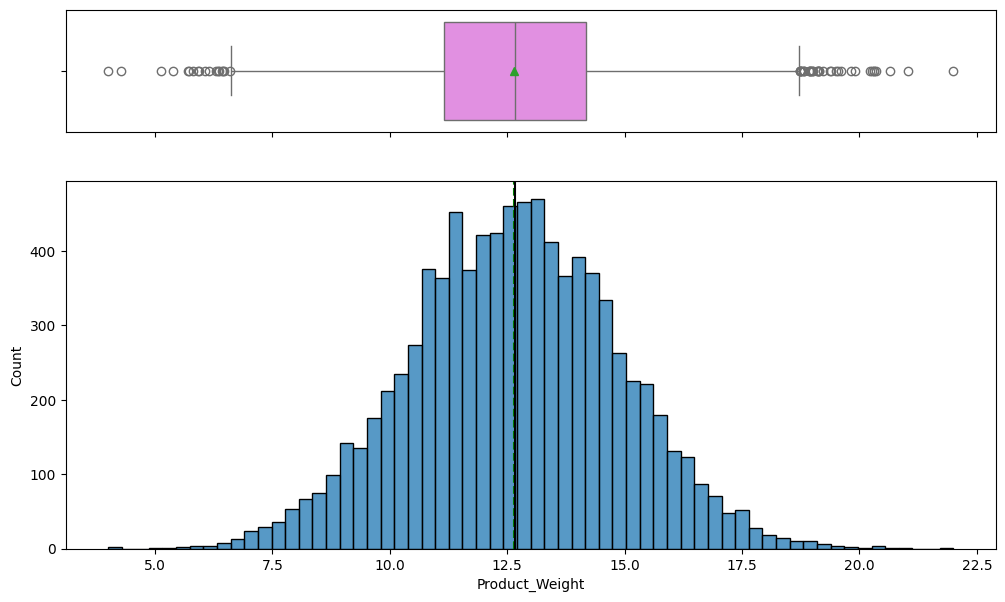

```python
histogram_boxplot(data, "Product_Weight")
```

**Observation:**

**Product_Allocated_Area**

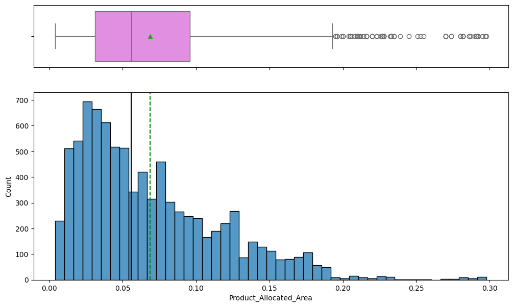

```python
histogram_boxplot(data, "Product_Allocated_Area")
```

**Observation:**

- The distribution is right skewed with the median lying around 0.05.

**Product_MRP**

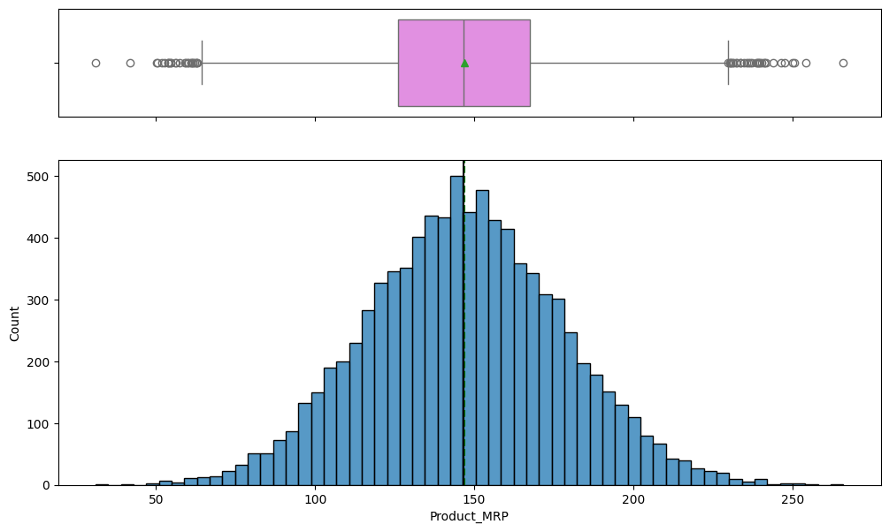

```python
histogram_boxplot(data, "Product_MRP")
```

**Observation:**

**Product_Store_Sales_Total**

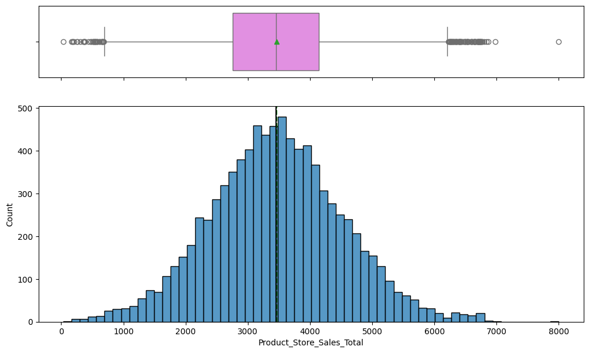

```python
histogram_boxplot(data, "Product_Store_Sales_Total")
```

**Observation:**

- The revenue generated from each product at a particular store is normally distributed with mean and median lying around 3500.

```python
# Function to create labeled barplots

def labeled_barplot(data, feature, perc = False, n = None):
    """
    Barplot with percentage at the top

    data: dataframe
    feature: dataframe column
    perc: whether to display percentages instead of count (default is False)
    n: displays the top n category levels (default is None, i.e., display all levels)
    """

    total = len(data[feature])            # Length of the column
    count = data[feature].nunique()
    if n is None:
        plt.figure(figsize = (count + 1, 5))
    else:
        plt.figure(figsize = (n + 1, 5))

    plt.xticks(rotation = 90, fontsize = 15)
    ax = sns.countplot(
        data = data,
        x = feature,
        palette = "Paired",
        order = data[feature].value_counts().index[:n].sort_values(),
    )

    for p in ax.patches:
        if perc == True:
            label = "{:.1f}%".format(
                100 * p.get_height() / total
            )                              # Percentage of each class of the category
        else:
            label = p.get_height()         # Count of each level of the category

        x = p.get_x() + p.get_width() / 2  # Width of the plot
        y = p.get_height()                 # Height of the plot

        ax.annotate(
            label,
            (x, y),
            ha = "center",
            va = "center",
            size = 12,
            xytext = (0, 5),
            textcoords = "offset points",
        )                                 # Annotate the percentage

    plt.show()                            # Show the plot
```

**Product_Sugar_Content**

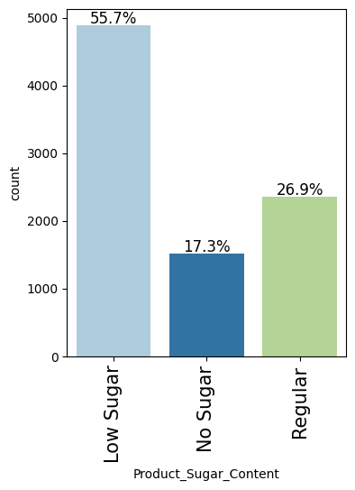

```python
labeled_barplot(data, "Product_Sugar_Content", perc = True)
```

**Observations:**

- Around 56% of the products are having low sugar followed by 27% products which are having regular sugar content.
- Around 17% of the products are having no sugar content.

**Product_Type**

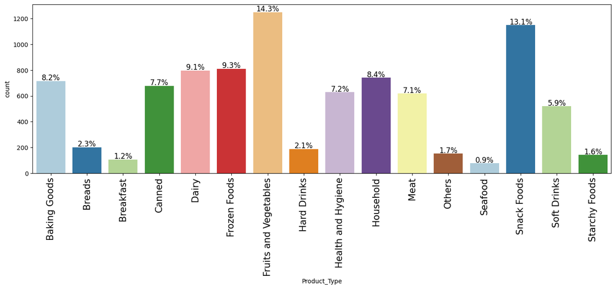

```python
labeled_barplot(data, "Product_Type", perc = True)
```

**Observations:**

**Store_Id**

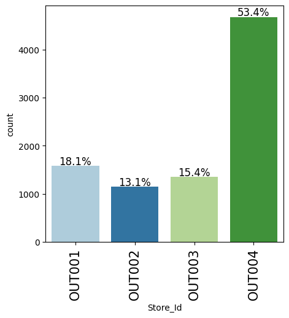

```python
labeled_barplot(data, "Store_Id", perc = True)
```

**Observations:**

- Around 53% of the products are being sold from outlet OUT004. An almost equal number of products have been sold from the other three stores each.
- When compared to the four Store_Ids the products, which are being sold from outlet OUT002 are low.

**Store_Size**

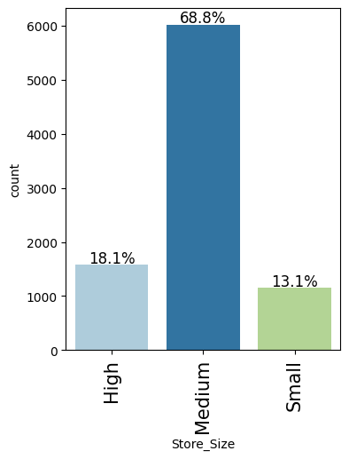

```python
labeled_barplot(data, "Store_Size", perc = True)
```

**Observations:**

- Around 69% of the products have been sold from the stores which are medium in size
- The products that have been sold from the stores which are high and small are almost the same in size.

**Store_Location_City_Type**

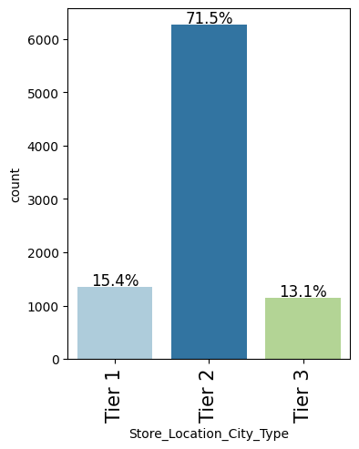

```python
labeled_barplot(data, "Store_Location_City_Type", perc = True)
```

**Observations:**

- Around 72% of the products have been sold from stores which are located in Tier 2 cities.
- The products that have been sold from the stores are located in Tier 1 and Tier 3 cities are almost the same.

**Store_Type**

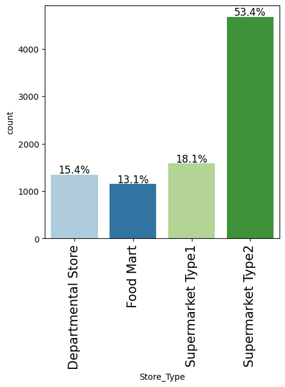

```python
labeled_barplot(data, "Store_Type", perc = True)
```

**Observations:**

- Around 53% of the products have been sold from stores that are of Supermarket Type2.
- The products that have been sold from stores which are of Supermarket Type1, Food Mart and Departmental Store are almost same.

### **Bivariate Analysis**

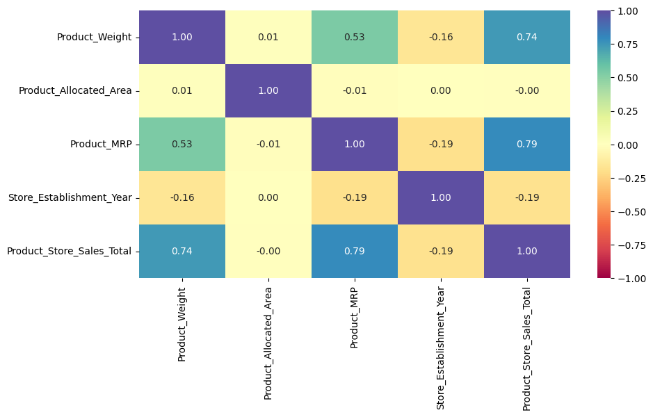

```python
cols_list = data.select_dtypes(include = np.number).columns.tolist()

plt.figure(figsize = (10, 5))
sns.heatmap(
    data[cols_list].corr(), annot = True, vmin = -1, vmax = 1, fmt = ".2f", cmap = "Spectral"
)
plt.show()
```

**Observations:**

**Let's check the distribution of our target variable i.e Product_Store_Sales_Total with the numeric columns**

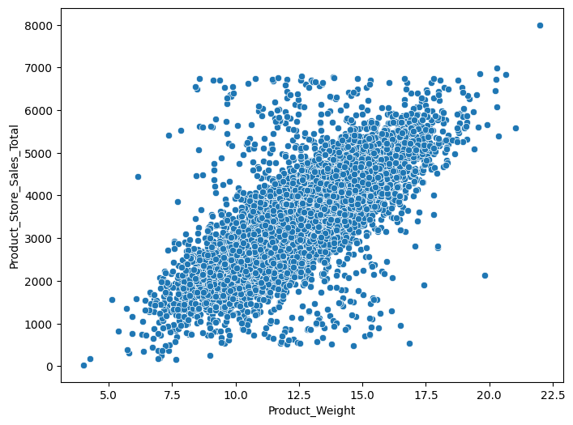

```python
plt.figure(figsize = [8, 6])
sns.scatterplot(x = data.Product_Weight, y = data.Product_Store_Sales_Total)
plt.show()
```

**Observation:**

- Product_Weight and Product_Store_Sales_Total are almost linearly correlated with each other.

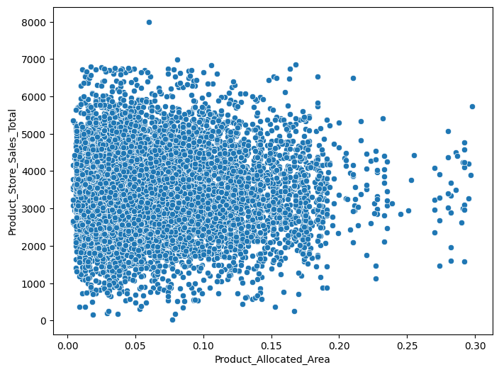

```python
plt.figure(figsize = [8, 6])
sns.scatterplot(x = data.Product_Allocated_Area, y = data.Product_Store_Sales_Total)
plt.show()
```

**Observation:**

- There seem to be no relationship between Product_Allocated_Area and Product_Store_Sales_Total.

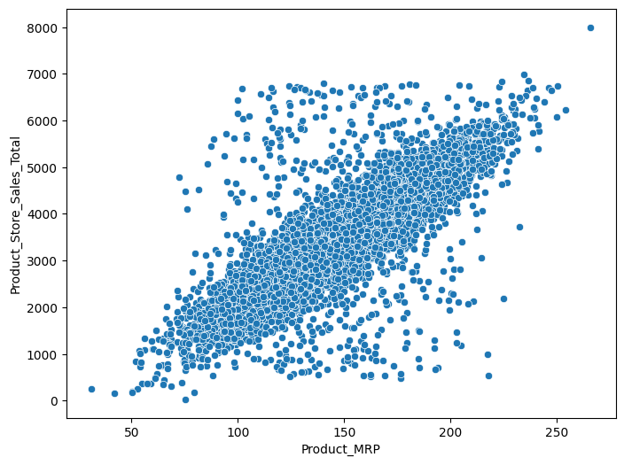

```python
plt.figure(figsize = [8, 6])
sns.scatterplot(x = data.Product_MRP, y = data.Product_Store_Sales_Total)
plt.show()
```

**Observation:**

- Product_MRP and Product_Store_Sales_Total are almost linearly correlated with each other.

**Let us see from which product type the company is generating most of the revenue**

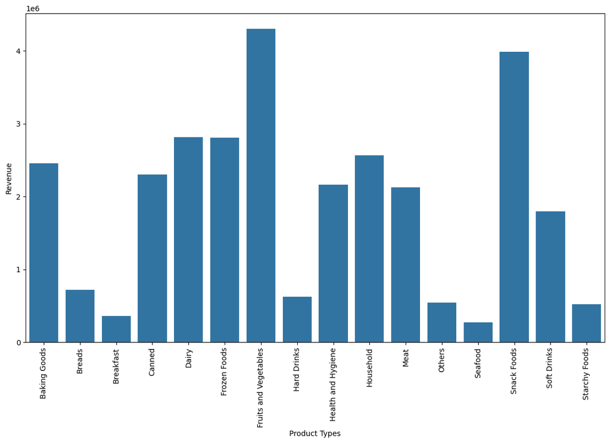

```python
df_revenue1 = data.groupby(["Product_Type"], as_index = False)[
    "Product_Store_Sales_Total"
].sum()
plt.figure(figsize = [14, 8])
plt.xticks(rotation = 90)
a = sns.barplot(x = df_revenue1.Product_Type, y = df_revenue1.Product_Store_Sales_Total)
a.set_xlabel("Product Types")
a.set_ylabel("Revenue")
plt.show()
```

**Observations:**

- Fruits and vegetables and snack foods are the biggest contributors to the revenue of the company(SuperKart).
- Seafood is the lowest contributor to the revenue of the company(SuperKart).
- Dairy and Frozen foods are contributing almost the same to the revenue of the company.

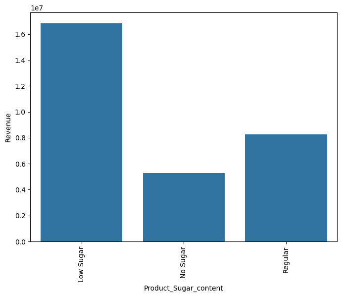

```python
df_revenue2 = data.groupby(["Product_Sugar_Content"], as_index = False)[
    "Product_Store_Sales_Total"
].sum()
plt.figure(figsize = [8, 6])
plt.xticks(rotation = 90)
b = sns.barplot(
    x = df_revenue2.Product_Sugar_Content, y = df_revenue2.Product_Store_Sales_Total
)
b.set_xlabel("Product_Sugar_content")
b.set_ylabel("Revenue")
plt.show()
```

**Observations:**

- Low sugar content materials are the biggest contributors to the revenue of the company(SuperKart).
- No Sugar content materials are the lowest contributors to the revenue of the company(SuperKart).

**Let us see from which type of stores and locations the revenue generation is more**.

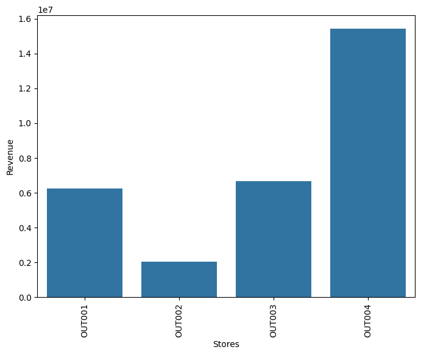

```python
df_store_revenue = data.groupby(["Store_Id"], as_index = False)[
    "Product_Store_Sales_Total"
].sum()
plt.figure(figsize = [8, 6])
plt.xticks(rotation = 90)
r = sns.barplot(
    x = df_store_revenue.Store_Id, y = df_store_revenue.Product_Store_Sales_Total
)
r.set_xlabel("Stores")
r.set_ylabel("Revenue")
plt.show()
```

**Observations:**

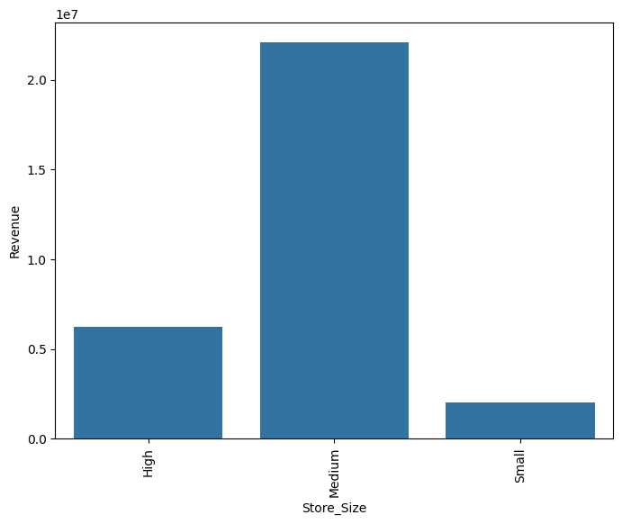

```python
df_revenue3 = data.groupby(["Store_Size"], as_index = False)[
    "Product_Store_Sales_Total"
].sum()
plt.figure(figsize = [8, 6])
plt.xticks(rotation = 90)
c = sns.barplot(x = df_revenue3.Store_Size, y = df_revenue3.Product_Store_Sales_Total)
c.set_xlabel("Store_Size")
c.set_ylabel("Revenue")
plt.show()
```

**Observations:**

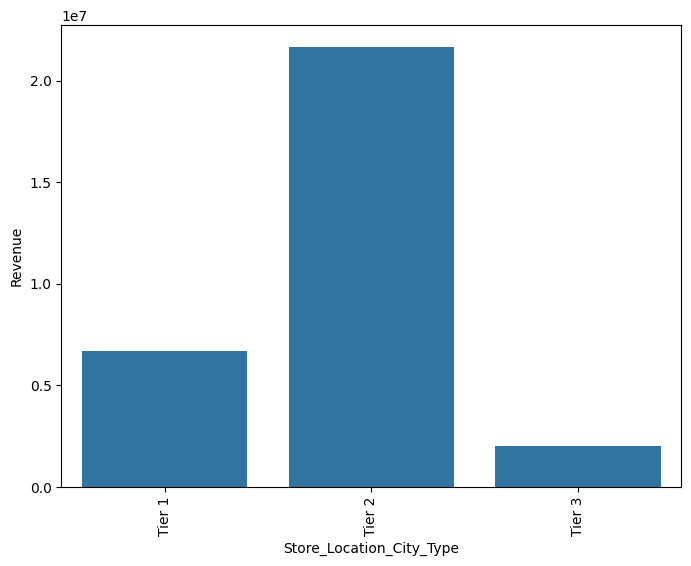

```python
df_revenue4 = data.groupby(["Store_Location_City_Type"], as_index = False)[
    "Product_Store_Sales_Total"
].sum()
plt.figure(figsize = [8, 6])
plt.xticks(rotation = 90)
d = sns.barplot(
    x = df_revenue4.Store_Location_City_Type, y = df_revenue4.Product_Store_Sales_Total
)
d.set_xlabel("Store_Location_City_Type")
d.set_ylabel("Revenue")
plt.show()
```

**Observations:**

- Stores in the Tier 2 cities are contributing the most to the revenue of SuperKart.
- Stores in the Tier 3 cities are contributing the least to the revenue of SuperKart.

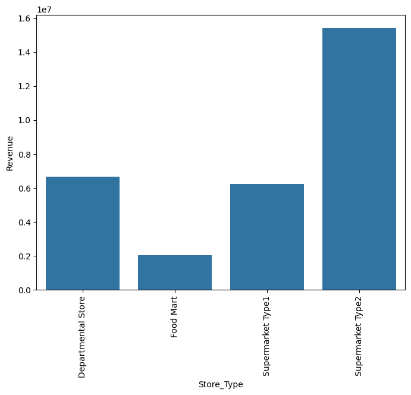

```python
df_revenue5 = data.groupby(["Store_Type"], as_index = False)[
    "Product_Store_Sales_Total"
].sum()
plt.figure(figsize = [8, 6])
plt.xticks(rotation = 90)
e = sns.barplot(x=df_revenue5.Store_Type, y = df_revenue5.Product_Store_Sales_Total)
e.set_xlabel("Store_Type")
e.set_ylabel("Revenue")
plt.show()
```

**Observations:**

- Stores of Supermarket Type 2 are performing exceptionally well.
- Stores of SuperKart Type 1 and Departmental Store are almost contributing the same revenue to the company.

**Let's check the distribution of our target variable i.e Product_Store_Sales_Total with the other categorical columns**

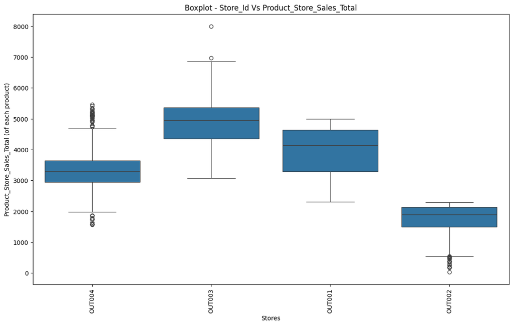

```python
plt.figure(figsize = [14, 8])
sns.boxplot(data = data, x = data.Store_Id, y = data.Product_Store_Sales_Total)
plt.xticks(rotation = 90)
plt.title("Boxplot - Store_Id Vs Product_Store_Sales_Total")
plt.xlabel("Stores")
plt.ylabel("Product_Store_Sales_Total (of each product)")
plt.show()
```

**Observations:**

- Although the number of products bought from OUT003 is around 15% only, however more costly goods have been bought from this store than the other stores. This shows that this is a premium store for the company.
- From the store OUT002 the low cost goods have been bought than the other stores. This store has less contribution to the company.

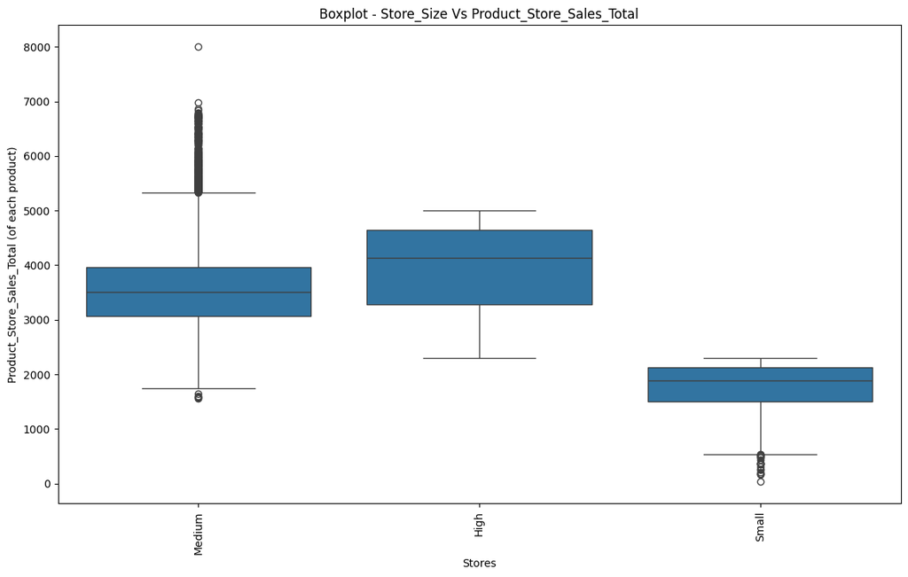

```python
plt.figure(figsize = [14, 8])
sns.boxplot(data = data, x = data.Store_Size, y = data.Product_Store_Sales_Total)
plt.xticks(rotation = 90)
plt.title("Boxplot - Store_Size Vs Product_Store_Sales_Total")
plt.xlabel("Stores")
plt.ylabel("Product_Store_Sales_Total (of each product)")
plt.show()
```

**Observation:**

- More costly goods have been bought from the stores which are high in size which seems to be quite logical.

**Let's now try to find out some relationship between the other columns**

**Generally certain product types will have higher product weight than others. Let's have a look.**

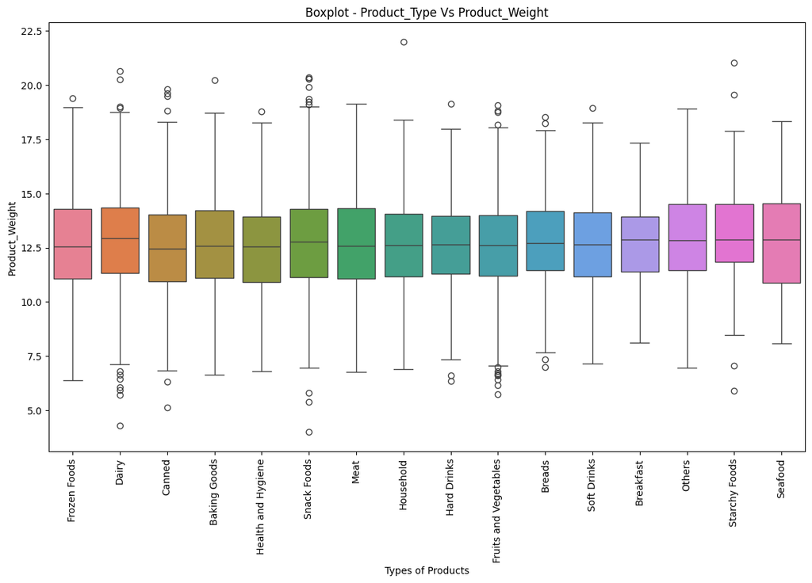

```python
plt.figure(figsize = [14, 8])
sns.boxplot(data = data, x = data.Product_Type, y = data.Product_Weight, hue=data.Product_Type)
plt.xticks(rotation = 90)
plt.title("Boxplot - Product_Type Vs Product_Weight")
plt.xlabel("Types of Products")
plt.ylabel("Product_Weight")
plt.show()
```

**Observation:**

- The median weight of all the product types is almost equal. Each product type contains different items whose weight ranges from low to high, therefore the overall weight of the product category gets averaged out.

**Let's find out whether there is some relationship between the weight of the product and its sugar content**

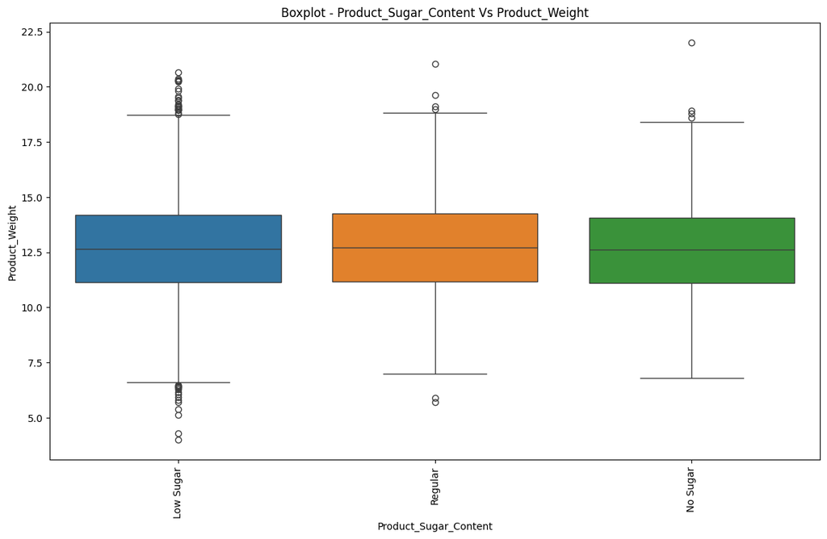

```python
plt.figure(figsize = [14, 8])
sns.boxplot(data = data, x = data.Product_Sugar_Content, y = data.Product_Weight, hue= data.Product_Sugar_Content)
plt.xticks(rotation = 90)
plt.title("Boxplot - Product_Sugar_Content Vs Product_Weight")
plt.xlabel("Product_Sugar_Content")
plt.ylabel("Product_Weight")
plt.show()
```

**Observation:**

- The median weight of all the products across the 3 categories is almost the same.

**Let's analyze the sugar content of different product types**

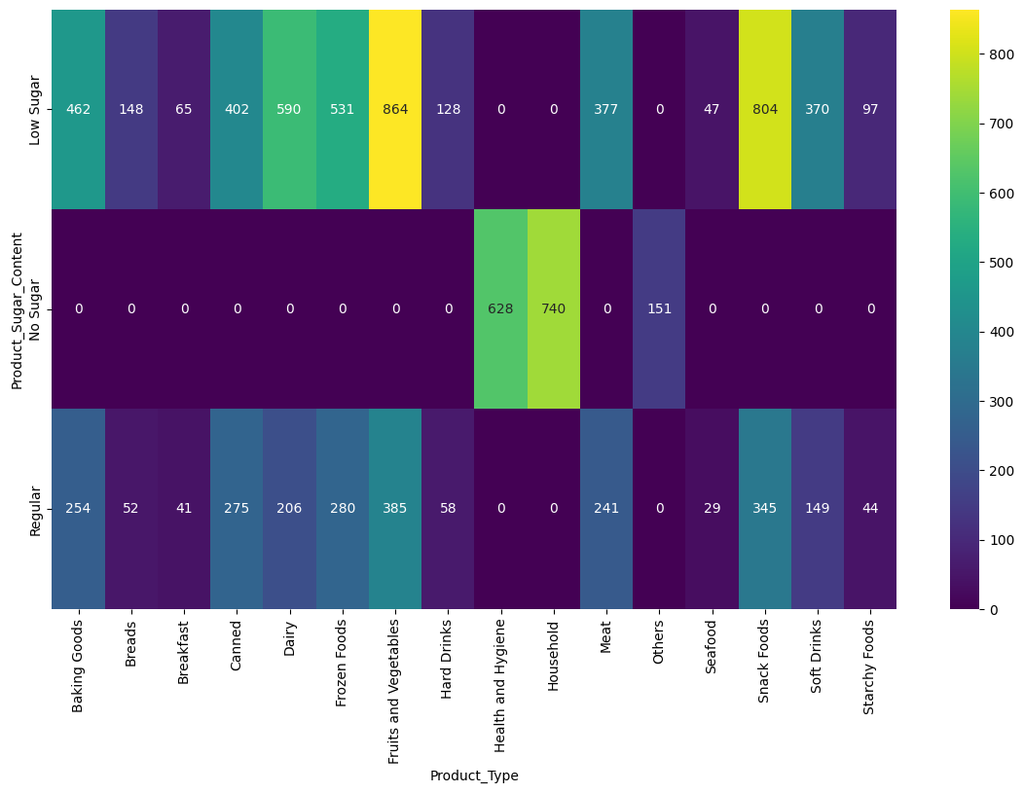

```python
plt.figure(figsize = (14, 8))
sns.heatmap(
    pd.crosstab(data["Product_Sugar_Content"], data["Product_Type"]),
    annot = True,
    fmt = "g",
    cmap = "viridis",
)
plt.ylabel("Product_Sugar_Content")
plt.xlabel("Product_Type")
plt.show()
```

**Observation:**

- Health and hygiene, household, and others are the only categories that have no sugar in them.

**Let's find out how many items of each product type has been sold in each of the stores**

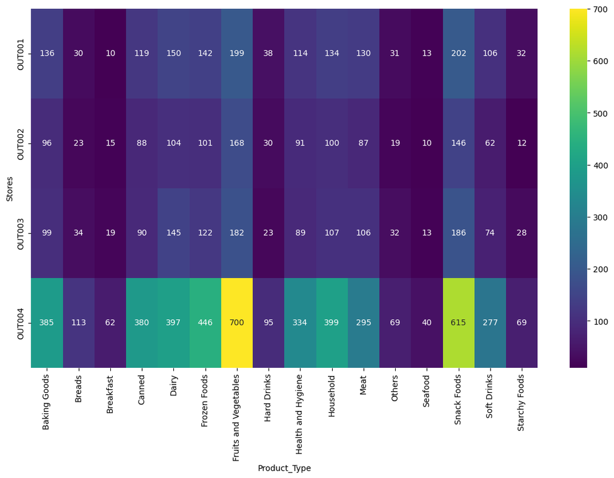

```python
plt.figure(figsize = (14, 8))
sns.heatmap(
    pd.crosstab(data["Store_Id"], data["Product_Type"]),
    annot = True,
    fmt = "g",
    cmap = "viridis",
)
plt.ylabel("Stores")
plt.xlabel("Product_Type")
plt.show()
```

**Observations:**

- Fruits and vegetables have been sold the most across all the stores followed by snack foods.
- Seafood is the least bought product type across all the stores.

**Different product types have different prices. Let's analyze the trend.**

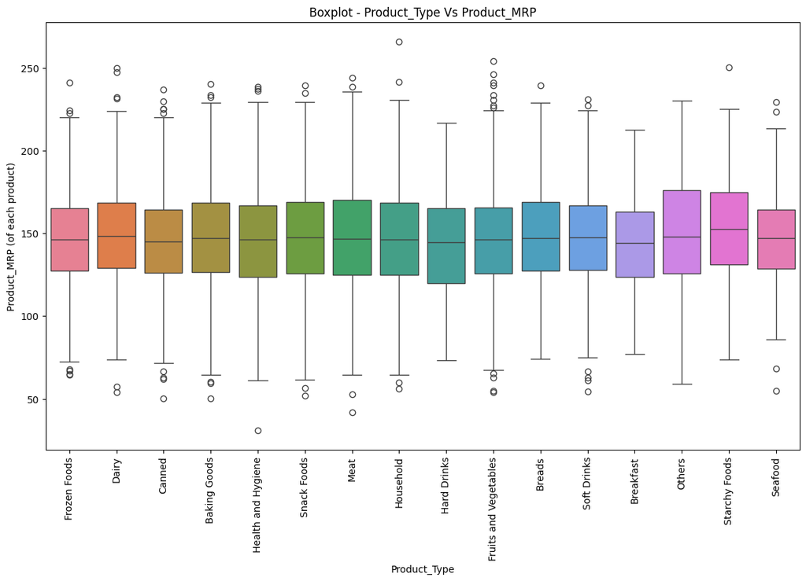

```python
plt.figure(figsize = [14, 8])
sns.boxplot(data = data, x = data.Product_Type, y = data.Product_MRP, hue = data.Product_Type)
plt.xticks(rotation = 90)
plt.title("Boxplot - Product_Type Vs Product_MRP")
plt.xlabel("Product_Type")
plt.ylabel("Product_MRP (of each product)")
plt.show()
```

**Observation:**

- The median MRPs of all the product types are almost equal. Each product type contains different items whose price ranges from low to high, therefore, the overall MRP of the product category gets averaged out.

**Let's find out how the Product_MRP varies with the different stores**

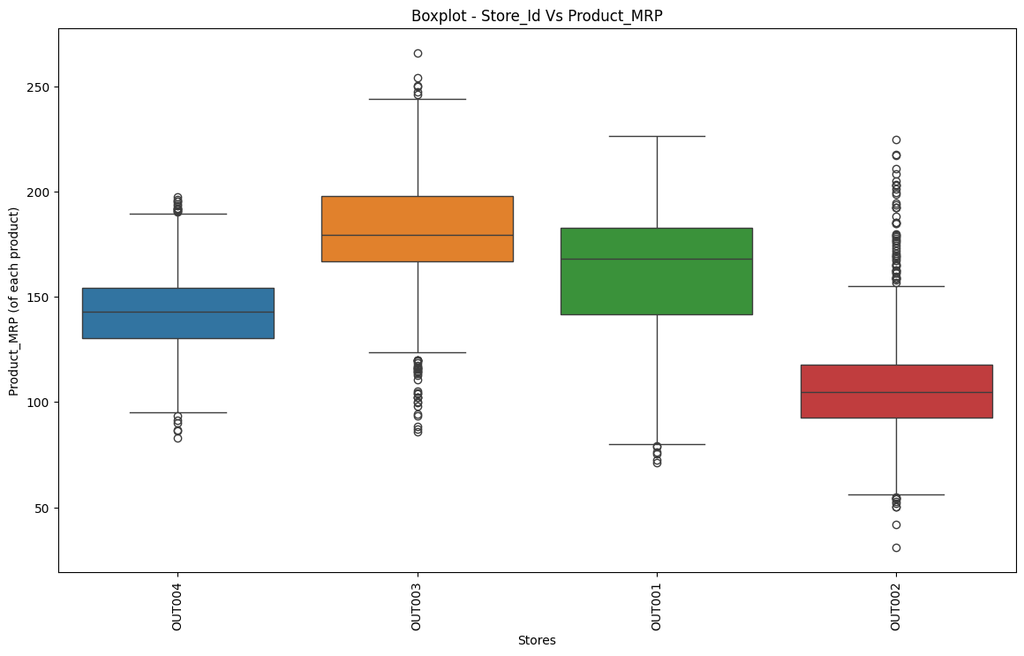

```python
plt.figure(figsize = [14, 8])
sns.boxplot(data = data, x = data.Store_Id, y = data.Product_MRP, hue = data.Store_Id )
plt.xticks(rotation = 90)
plt.title("Boxplot - Store_Id Vs Product_MRP")
plt.xlabel("Stores")
plt.ylabel("Product_MRP (of each product)")
plt.show()
```

**Observation:**

- As we have seen earlier OUT003, being a premium store, has more costly items than the rest of the stores.

**Let's delve deeper and do a detailed analysis of each of the stores**.

**OUT001**

```python
data.loc[data["Store_Id"] == "OUT001"].describe(include = "all").T
```

|  | count | unique | top | freq | mean | std | min | 25% | 50% | 75% | max |
| --- | --- | --- | --- | --- | --- | --- | --- | --- | --- | --- | --- |
| Product_Weight | 1586.0 | NaN | NaN | NaN | 13.458865 | 2.064975 | 6.16 | 12.0525 | 13.96 | 14.95 | 17.97 |
| Product_Sugar_Content | 1586 | 3 | Low Sugar | 845 | NaN | NaN | NaN | NaN | NaN | NaN | NaN |
| Product_Allocated_Area | 1586.0 | NaN | NaN | NaN | 0.068768 | 0.047131 | 0.004 | 0.033 | 0.0565 | 0.094 | 0.295 |
| Product_Type | 1586 | 16 | Snack Foods | 202 | NaN | NaN | NaN | NaN | NaN | NaN | NaN |
| Product_MRP | 1586.0 | NaN | NaN | NaN | 160.514054 | 30.359059 | 71.35 | 141.72 | 168.32 | 182.9375 | 226.59 |
| Store_Id | 1586 | 1 | OUT001 | 1586 | NaN | NaN | NaN | NaN | NaN | NaN | NaN |
| Store_Establishment_Year | 1586.0 | NaN | NaN | NaN | 1987.0 | 0.0 | 1987.0 | 1987.0 | 1987.0 | 1987.0 | 1987.0 |
| Store_Size | 1586 | 1 | High | 1586 | NaN | NaN | NaN | NaN | NaN | NaN | NaN |
| Store_Location_City_Type | 1586 | 1 | Tier 2 | 1586 | NaN | NaN | NaN | NaN | NaN | NaN | NaN |
| Store_Type | 1586 | 1 | Supermarket Type1 | 1586 | NaN | NaN | NaN | NaN | NaN | NaN | NaN |
| Product_Store_Sales_Total | 1586.0 | NaN | NaN | NaN | 3923.778802 | 904.62901 | 2300.56 | 3285.51 | 4139.645 | 4639.4 | 4997.63 |
| Product_Id_char | 1586 | 3 | FD | 1163 | NaN | NaN | NaN | NaN | NaN | NaN | NaN |

**Observations:**

- OUT001 is a store of Supermarket Type 1 which is located in a Tier 2 city and has a store size as high. It was established in 1987.
- OUT001 has sold products whose MRP ranges from 71 to 227.
- Snack Foods have been sold the highest number of times in OUT001.
- The revenue generated from each product at OUT001 ranges from 2300 to 5000.
- The Product_Type has more unique values when compared to other variables considered.

```python
data.loc[data["Store_Id"] == "OUT001", "Product_Store_Sales_Total"].sum()
```

```
6223113.18
```

**OUT001 has generated total revenue of 6,223,113 from the sales of goods.**

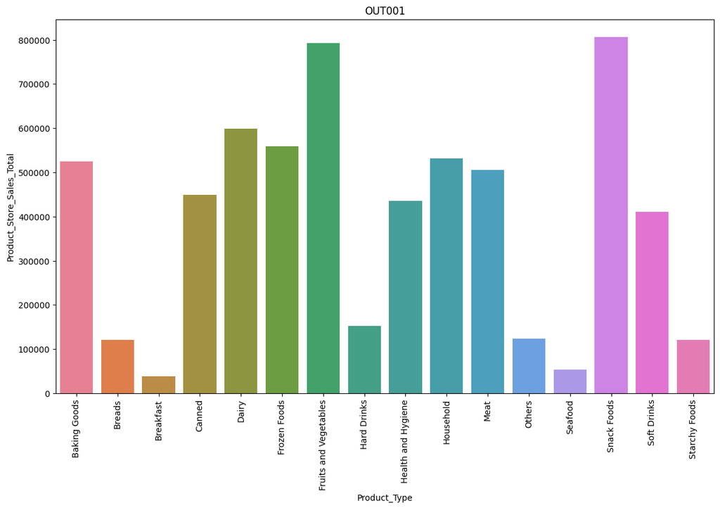

```python
df_OUT001 = (
    data.loc[data["Store_Id"] == "OUT001"]
    .groupby(["Product_Type"], as_index = False)["Product_Store_Sales_Total"]
    .sum()
)
plt.figure(figsize = [14, 8])
plt.xticks(rotation = 90)
plt.xlabel("Product_Type")
plt.ylabel("Product_Store_Sales_Total")
plt.title("OUT001")
sns.barplot(x = df_OUT001.Product_Type, y = df_OUT001.Product_Store_Sales_Total, hue=df_OUT001.Product_Type)
plt.show()
```

**OUT002**

```python
data.loc[data["Store_Id"] == "OUT002"].describe(include = "all").T
```

|  | count | unique | top | freq | mean | std | min | 25% | 50% | 75% | max |
| --- | --- | --- | --- | --- | --- | --- | --- | --- | --- | --- | --- |
| Product_Weight | 1152.0 | NaN | NaN | NaN | 9.911241 | 1.799846 | 4.0 | 8.7675 | 9.795 | 10.89 | 19.82 |
| Product_Sugar_Content | 1152 | 3 | Low Sugar | 658 | NaN | NaN | NaN | NaN | NaN | NaN | NaN |
| Product_Allocated_Area | 1152.0 | NaN | NaN | NaN | 0.067747 | 0.047567 | 0.006 | 0.031 | 0.0545 | 0.09525 | 0.292 |
| Product_Type | 1152 | 16 | Fruits and Vegetables | 168 | NaN | NaN | NaN | NaN | NaN | NaN | NaN |
| Product_MRP | 1152.0 | NaN | NaN | NaN | 107.080634 | 24.912333 | 31.0 | 92.8275 | 104.675 | 117.8175 | 224.93 |
| Store_Id | 1152 | 1 | OUT002 | 1152 | NaN | NaN | NaN | NaN | NaN | NaN | NaN |
| Store_Establishment_Year | 1152.0 | NaN | NaN | NaN | 1998.0 | 0.0 | 1998.0 | 1998.0 | 1998.0 | 1998.0 | 1998.0 |
| Store_Size | 1152 | 1 | Small | 1152 | NaN | NaN | NaN | NaN | NaN | NaN | NaN |
| Store_Location_City_Type | 1152 | 1 | Tier 3 | 1152 | NaN | NaN | NaN | NaN | NaN | NaN | NaN |
| Store_Type | 1152 | 1 | Food Mart | 1152 | NaN | NaN | NaN | NaN | NaN | NaN | NaN |
| Product_Store_Sales_Total | 1152.0 | NaN | NaN | NaN | 1762.942465 | 462.862431 | 33.0 | 1495.4725 | 1889.495 | 2133.6225 | 2299.63 |
| Product_Id_char | 1152 | 3 | FD | 850 | NaN | NaN | NaN | NaN | NaN | NaN | NaN |

**Observations:**

- OUT002 is a food mart which is located in a Tier 3 city and has store size as small. It was established in 1998.
- OUT002 has sold products whose MRP ranges from 31 to 225.
- Fruits and vegetables have been sold the highest number of times in OUT002.
- The revenue generated from each product at OUT002 ranges from 33 to 2300.
- The frequency of each variable ranges from 168 to 1152.

```python
data.loc[data["Store_Id"] == "OUT002", "Product_Store_Sales_Total"].sum()
```

```
2030909.72
```

**OUT002 has generated total revenue of 2,030,910 from the sales of goods.**

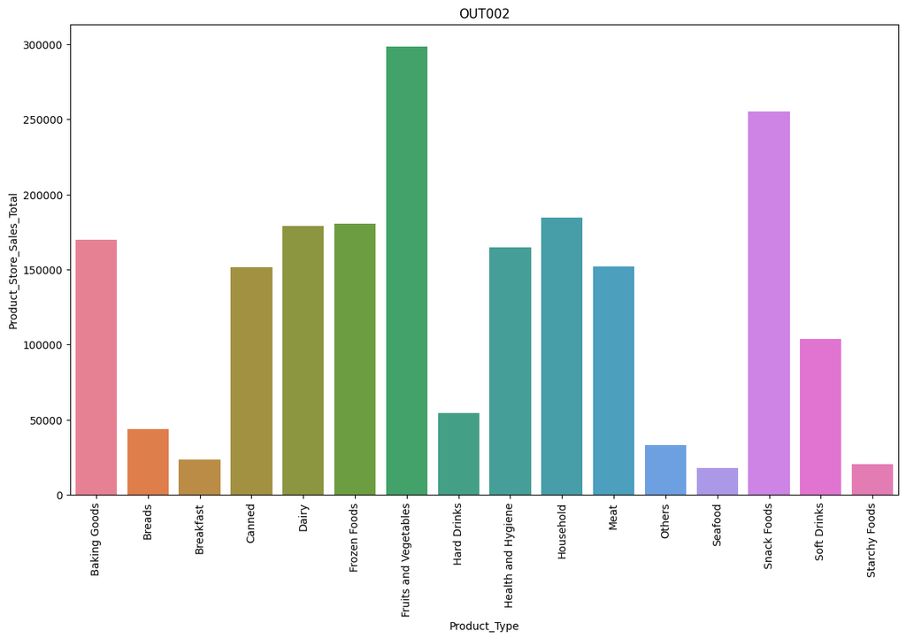

```python
df_OUT002 = (
    data.loc[data["Store_Id"] == "OUT002"]
    .groupby(["Product_Type"], as_index = False)["Product_Store_Sales_Total"]
    .sum()
)
plt.figure(figsize = [14, 8])
plt.xticks(rotation = 90)
plt.xlabel("Product_Type")
plt.ylabel("Product_Store_Sales_Total")
plt.title("OUT002")
sns.barplot(x = df_OUT002.Product_Type, y = df_OUT002.Product_Store_Sales_Total, hue=df_OUT002.Product_Type )
plt.show()
```

**Observations:**

- OUT002 has generated the highest revenue from the sale of fruits and vegetables (~ 300000) followed by snack foods (~ 250000).
- OUT002 has generated the lowest revenue from the sale of seafood and starchy foods followed by breakfast.

**OUT003**

```python
data.loc[data["Store_Id"] == "OUT003"].describe(include = "all").T
```

|  | count | unique | top | freq | mean | std | min | 25% | 50% | 75% | max |
| --- | --- | --- | --- | --- | --- | --- | --- | --- | --- | --- | --- |
| Product_Weight | 1349.0 | NaN | NaN | NaN | 15.103692 | 1.893531 | 7.35 | 14.02 | 15.18 | 16.35 | 22.0 |
| Product_Sugar_Content | 1349 | 3 | Low Sugar | 750 | NaN | NaN | NaN | NaN | NaN | NaN | NaN |
| Product_Allocated_Area | 1349.0 | NaN | NaN | NaN | 0.068637 | 0.048708 | 0.004 | 0.031 | 0.057 | 0.094 | 0.298 |
| Product_Type | 1349 | 16 | Snack Foods | 186 | NaN | NaN | NaN | NaN | NaN | NaN | NaN |
| Product_MRP | 1349.0 | NaN | NaN | NaN | 181.358725 | 24.796429 | 85.88 | 166.92 | 179.67 | 198.07 | 266.0 |
| Store_Id | 1349 | 1 | OUT003 | 1349 | NaN | NaN | NaN | NaN | NaN | NaN | NaN |
| Store_Establishment_Year | 1349.0 | NaN | NaN | NaN | 1999.0 | 0.0 | 1999.0 | 1999.0 | 1999.0 | 1999.0 | 1999.0 |
| Store_Size | 1349 | 1 | Medium | 1349 | NaN | NaN | NaN | NaN | NaN | NaN | NaN |
| Store_Location_City_Type | 1349 | 1 | Tier 1 | 1349 | NaN | NaN | NaN | NaN | NaN | NaN | NaN |
| Store_Type | 1349 | 1 | Departmental Store | 1349 | NaN | NaN | NaN | NaN | NaN | NaN | NaN |
| Product_Store_Sales_Total | 1349.0 | NaN | NaN | NaN | 4946.966323 | 677.539953 | 3069.24 | 4355.39 | 4958.29 | 5366.59 | 8000.0 |
| Product_Id_char | 1349 | 3 | FD | 1024 | NaN | NaN | NaN | NaN | NaN | NaN | NaN |

**Observations**

- OUT003 is a Departmental store which is located in a Tier 1 city and has a store size of medium. It was established in 1999.
- OUT003 has sold products whose MRP ranges from 86 to 266.
- Snack Foods have been sold the highest number of times in OUT003.
- The revenue generated from each product at OUT003 ranges from 3070 to 8000.
- The frequency of all the variables is in the range of 186 to 1349.

```python
data.loc[data["Store_Id"] == "OUT003", "Product_Store_Sales_Total"].sum()
```

```
6673457.57
```

**OUT003 has generated total revenue of 6,673,458 from the sales of goods.**

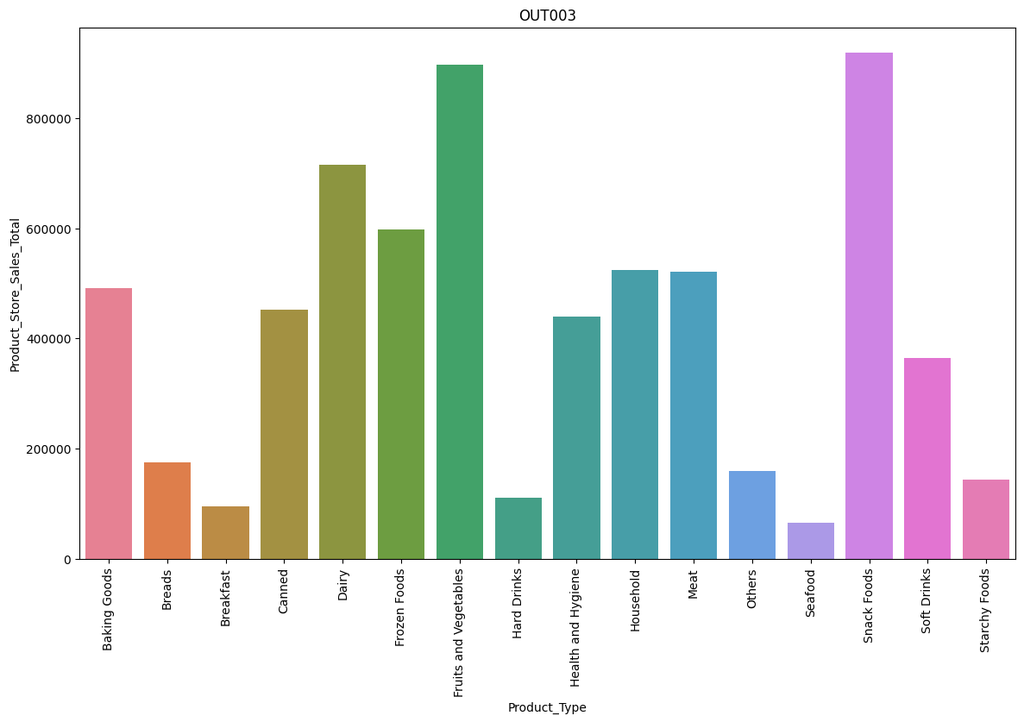

```python
df_OUT003 = (
    data.loc[data["Store_Id"] == "OUT003"]
    .groupby(["Product_Type"], as_index = False)["Product_Store_Sales_Total"]
    .sum()
)
plt.figure(figsize = [14, 8])
plt.xticks(rotation = 90)
plt.xlabel("Product_Type")
plt.ylabel("Product_Store_Sales_Total")
plt.title("OUT003")
sns.barplot(x = df_OUT003.Product_Type, y = df_OUT003.Product_Store_Sales_Total, hue=df_OUT003.Product_Type)
plt.show()
```

**OUT004**

```python
data.loc[data["Store_Id"] == "OUT004"].describe(include = "all").T
```

|  | count | unique | top | freq | mean | std | min | 25% | 50% | 75% | max |
| --- | --- | --- | --- | --- | --- | --- | --- | --- | --- | --- | --- |
| Product_Weight | 4676.0 | NaN | NaN | NaN | 12.349613 | 1.428199 | 7.34 | 11.37 | 12.37 | 13.3025 | 17.79 |
| Product_Sugar_Content | 4676 | 3 | Low Sugar | 2632 | NaN | NaN | NaN | NaN | NaN | NaN | NaN |
| Product_Allocated_Area | 4676.0 | NaN | NaN | NaN | 0.069092 | 0.048584 | 0.004 | 0.031 | 0.056 | 0.097 | 0.297 |
| Product_Type | 4676 | 16 | Fruits and Vegetables | 700 | NaN | NaN | NaN | NaN | NaN | NaN | NaN |
| Product_MRP | 4676.0 | NaN | NaN | NaN | 142.399709 | 17.513973 | 83.04 | 130.54 | 142.82 | 154.1925 | 197.66 |
| Store_Id | 4676 | 1 | OUT004 | 4676 | NaN | NaN | NaN | NaN | NaN | NaN | NaN |
| Store_Establishment_Year | 4676.0 | NaN | NaN | NaN | 2009.0 | 0.0 | 2009.0 | 2009.0 | 2009.0 | 2009.0 | 2009.0 |
| Store_Size | 4676 | 1 | Medium | 4676 | NaN | NaN | NaN | NaN | NaN | NaN | NaN |
| Store_Location_City_Type | 4676 | 1 | Tier 2 | 4676 | NaN | NaN | NaN | NaN | NaN | NaN | NaN |
| Store_Type | 4676 | 1 | Supermarket Type2 | 4676 | NaN | NaN | NaN | NaN | NaN | NaN | NaN |
| Product_Store_Sales_Total | 4676.0 | NaN | NaN | NaN | 3299.312111 | 468.271692 | 1561.06 | 2942.085 | 3304.18 | 3646.9075 | 5462.86 |
| Product_Id_char | 4676 | 3 | FD | 3502 | NaN | NaN | NaN | NaN | NaN | NaN | NaN |

**Observations:**

- OUT004 is a store of Supermarket Type2 which is located in a Tier 2 city and has store size as medium. It was established in 2009.
- OUT004 has sold products whose MRP range from 83 to 198.
- Fruits and vegetables have been sold the highest number of times in OUT004.
- The revenue generated from each product at OUT004 ranges from 1561 to 5463.
- The frequency of all the variables in OUT004 is in the range from 700 to 4676.

```python
data.loc[data["Store_Id"] == "OUT004", "Product_Store_Sales_Total"].sum()
```

```
15427583.43
```

**OUT004 has generated total revenue of 15427583 from the sales of goods which is highest among all the 4 stores.**

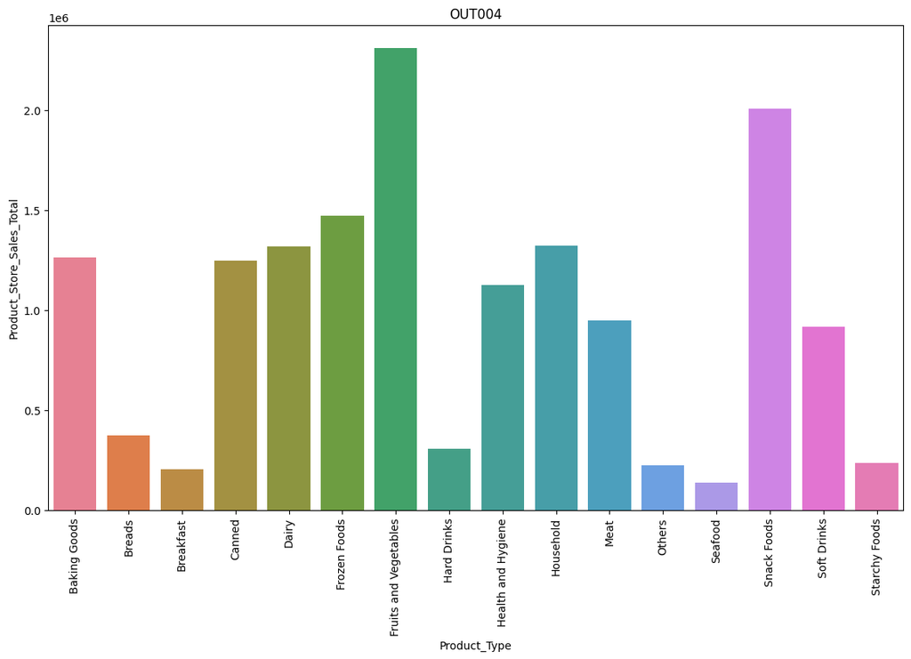

```python
df_OUT004 = (
    data.loc[data["Store_Id"] == "OUT004"]
    .groupby(["Product_Type"], as_index = False)["Product_Store_Sales_Total"]
    .sum()
)
plt.figure(figsize = [14, 8])
plt.xticks(rotation = 90)
plt.xlabel("Product_Type")
plt.ylabel("Product_Store_Sales_Total")
plt.title("OUT004")
sns.barplot(x = df_OUT004.Product_Type, y = df_OUT004.Product_Store_Sales_Total, hue=df_OUT004.Product_Type)
plt.show()
```

**Let's find out the revenue generated by the stores from each of the product types**.

```python
df1 = data.groupby(["Product_Type", "Store_Id"], as_index = False)[
    "Product_Store_Sales_Total"
].sum()
df1
```

|  | Product_Type | Store_Id | Product_Store_Sales_Total |
| --- | --- | --- | --- |
| 0 | Baking Goods | OUT001 | 525131.04 |
| 1 | Baking Goods | OUT002 | 169860.50 |
| 2 | Baking Goods | OUT003 | 491908.20 |
| 3 | Baking Goods | OUT004 | 1266086.26 |
| 4 | Breads | OUT001 | 121274.09 |
| 5 | Breads | OUT002 | 43419.47 |
| 6 | Breads | OUT003 | 175391.93 |
| 7 | Breads | OUT004 | 374856.75 |
| 8 | Breakfast | OUT001 | 38161.10 |
| 9 | Breakfast | OUT002 | 23396.10 |
| 10 | Breakfast | OUT003 | 95634.08 |
| 11 | Breakfast | OUT004 | 204939.13 |
| 12 | Canned | OUT001 | 449016.38 |
| 13 | Canned | OUT002 | 151467.66 |
| 14 | Canned | OUT003 | 452445.17 |
| 15 | Canned | OUT004 | 1247153.50 |
| 16 | Dairy | OUT001 | 598767.62 |
| 17 | Dairy | OUT002 | 178888.18 |
| 18 | Dairy | OUT003 | 715814.94 |
| 19 | Dairy | OUT004 | 1318447.30 |
| 20 | Frozen Foods | OUT001 | 558556.81 |
| 21 | Frozen Foods | OUT002 | 180295.95 |
| 22 | Frozen Foods | OUT003 | 597608.42 |
| 23 | Frozen Foods | OUT004 | 1473519.65 |
| 24 | Fruits and Vegetables | OUT001 | 792992.59 |
| 25 | Fruits and Vegetables | OUT002 | 298503.56 |
| 26 | Fruits and Vegetables | OUT003 | 897437.46 |
| 27 | Fruits and Vegetables | OUT004 | 2311899.66 |
| 28 | Hard Drinks | OUT001 | 152920.74 |
| 29 | Hard Drinks | OUT002 | 54281.85 |
| 30 | Hard Drinks | OUT003 | 110760.30 |
| 31 | Hard Drinks | OUT004 | 307851.73 |
| 32 | Health and Hygiene | OUT001 | 435005.31 |
| 33 | Health and Hygiene | OUT002 | 164660.81 |
| 34 | Health and Hygiene | OUT003 | 439139.18 |
| 35 | Health and Hygiene | OUT004 | 1124901.91 |
| 36 | Household | OUT001 | 531371.38 |
| 37 | Household | OUT002 | 184665.65 |
| 38 | Household | OUT003 | 523981.64 |
| 39 | Household | OUT004 | 1324721.50 |
| 40 | Meat | OUT001 | 505867.28 |
| 41 | Meat | OUT002 | 151800.01 |
| 42 | Meat | OUT003 | 520939.68 |
| 43 | Meat | OUT004 | 950604.97 |
| 44 | Others | OUT001 | 123977.09 |
| 45 | Others | OUT002 | 32835.73 |
| 46 | Others | OUT003 | 159963.75 |
| 47 | Others | OUT004 | 224719.73 |
| 48 | Seafood | OUT001 | 52936.84 |
| 49 | Seafood | OUT002 | 17663.35 |
| 50 | Seafood | OUT003 | 65337.48 |
| 51 | Seafood | OUT004 | 136466.37 |
| 52 | Snack Foods | OUT001 | 806142.24 |
| 53 | Snack Foods | OUT002 | 255317.57 |
| 54 | Snack Foods | OUT003 | 918510.44 |
| 55 | Snack Foods | OUT004 | 2009026.70 |
| 56 | Soft Drinks | OUT001 | 410548.69 |
| 57 | Soft Drinks | OUT002 | 103808.35 |
| 58 | Soft Drinks | OUT003 | 365046.30 |
| 59 | Soft Drinks | OUT004 | 917641.38 |
| 60 | Starchy Foods | OUT001 | 120443.98 |
| 61 | Starchy Foods | OUT002 | 20044.98 |
| 62 | Starchy Foods | OUT003 | 143538.60 |
| 63 | Starchy Foods | OUT004 | 234746.89 |

**Let's find out the revenue generated by the stores from products having different levels of sugar content**.

```python
df2 = data.groupby(["Product_Sugar_Content", "Store_Id"], as_index = False)[
    "Product_Store_Sales_Total"
].sum()
df2
```

|  | Product_Sugar_Content | Store_Id | Product_Store_Sales_Total |
| --- | --- | --- | --- |
| 0 | Low Sugar | OUT001 | 3300834.93 |
| 1 | Low Sugar | OUT002 | 1156758.85 |
| 2 | Low Sugar | OUT003 | 3706903.24 |
| 3 | Low Sugar | OUT004 | 8658908.78 |
| 4 | No Sugar | OUT001 | 1090353.78 |
| 5 | No Sugar | OUT002 | 382162.19 |
| 6 | No Sugar | OUT003 | 1123084.57 |
| 7 | No Sugar | OUT004 | 2674343.14 |
| 8 | Regular | OUT001 | 1831924.47 |
| 9 | Regular | OUT002 | 491988.68 |
| 10 | Regular | OUT003 | 1843469.76 |
| 11 | Regular | OUT004 | 4094331.51 |

**Observation:**

- The trend is the same as that which was present in the revenue analysis of stores for product types.